# Risk Factor Analysis

## Outcome Variable

**Outcome Variable:** wast_rec90d

## Predictor Variables

**Intervention Variable:** exclfeed3

**Adjustment Set:**

- arm
- sex
- W_mage
- meducyrs
- feducyrs
- hhwealth_quart
- hfoodsec
- W_mhtcm
- vagbrth
- W_gagebrth
- W_birthwt
- W_birthlen
- W_nrooms
- W_nchldlt5
- month
- brthmon
- W_parity
- impfloor
- impsan
- safeh20
- delta_W_mage
- delta_meducyrs
- delta_feducyrs
- delta_hhwealth_quart
- delta_hfoodsec
- delta_W_mhtcm
- delta_vagbrth
- delta_W_gagebrth
- delta_W_birthwt
- delta_W_birthlen
- delta_W_nrooms
- delta_W_nchldlt5
- delta_month
- delta_brthmon
- delta_W_parity
- delta_impfloor
- delta_impsan
- delta_safeh20

## Stratifying Variables

The analysis was stratified on these variable(s):

- agecat
- studyid
- country

## Data Summary

| agecat | studyid | country | exclfeed3 | wast_rec90d | n_cell | n |
| --- | --- | --- | --- | --- | --- | --- |
| 0-24 months | ki0047075b-MAL-ED | BANGLADESH | 1 | 0 | 32 | 118 |
| 0-24 months | ki0047075b-MAL-ED | BANGLADESH | 1 | 1 | 62 | 118 |
| 0-24 months | ki0047075b-MAL-ED | BANGLADESH | 0 | 0 | 10 | 118 |
| 0-24 months | ki0047075b-MAL-ED | BANGLADESH | 0 | 1 | 14 | 118 |
| 0-24 months | ki0047075b-MAL-ED | BRAZIL | 1 | 0 | 3 | 23 |
| 0-24 months | ki0047075b-MAL-ED | BRAZIL | 1 | 1 | 6 | 23 |
| 0-24 months | ki0047075b-MAL-ED | BRAZIL | 0 | 0 | 3 | 23 |
| 0-24 months | ki0047075b-MAL-ED | BRAZIL | 0 | 1 | 11 | 23 |
| 0-24 months | ki0047075b-MAL-ED | INDIA | 1 | 0 | 34 | 177 |
| 0-24 months | ki0047075b-MAL-ED | INDIA | 1 | 1 | 65 | 177 |
| 0-24 months | ki0047075b-MAL-ED | INDIA | 0 | 0 | 36 | 177 |
| 0-24 months | ki0047075b-MAL-ED | INDIA | 0 | 1 | 42 | 177 |
| 0-24 months | ki0047075b-MAL-ED | NEPAL | 1 | 0 | 6 | 92 |
| 0-24 months | ki0047075b-MAL-ED | NEPAL | 1 | 1 | 21 | 92 |
| 0-24 months | ki0047075b-MAL-ED | NEPAL | 0 | 0 | 14 | 92 |
| 0-24 months | ki0047075b-MAL-ED | NEPAL | 0 | 1 | 51 | 92 |
| 0-24 months | ki0047075b-MAL-ED | PERU | 1 | 0 | 2 | 32 |
| 0-24 months | ki0047075b-MAL-ED | PERU | 1 | 1 | 3 | 32 |
| 0-24 months | ki0047075b-MAL-ED | PERU | 0 | 0 | 4 | 32 |
| 0-24 months | ki0047075b-MAL-ED | PERU | 0 | 1 | 23 | 32 |
| 0-24 months | ki0047075b-MAL-ED | SOUTH AFRICA | 1 | 0 | 1 | 78 |
| 0-24 months | ki0047075b-MAL-ED | SOUTH AFRICA | 1 | 1 | 3 | 78 |
| 0-24 months | ki0047075b-MAL-ED | SOUTH AFRICA | 0 | 0 | 12 | 78 |
| 0-24 months | ki0047075b-MAL-ED | SOUTH AFRICA | 0 | 1 | 62 | 78 |
| 0-24 months | ki0047075b-MAL-ED | TANZANIA, UNITED REPUBLIC OF | 1 | 0 | 1 | 45 |
| 0-24 months | ki0047075b-MAL-ED | TANZANIA, UNITED REPUBLIC OF | 1 | 1 | 12 | 45 |
| 0-24 months | ki0047075b-MAL-ED | TANZANIA, UNITED REPUBLIC OF | 0 | 0 | 7 | 45 |
| 0-24 months | ki0047075b-MAL-ED | TANZANIA, UNITED REPUBLIC OF | 0 | 1 | 25 | 45 |
| 0-24 months | ki1000108-CMC-V-BCS-2002 | INDIA | 1 | 0 | 5 | 11 |
| 0-24 months | ki1000108-CMC-V-BCS-2002 | INDIA | 1 | 1 | 6 | 11 |

[output cut: 162 more lines]

The following strata were considered:

- agecat: 0-24 months, studyid: ki0047075b-MAL-ED, country: BANGLADESH
- agecat: 0-24 months, studyid: ki0047075b-MAL-ED, country: BRAZIL
- agecat: 0-24 months, studyid: ki0047075b-MAL-ED, country: INDIA
- agecat: 0-24 months, studyid: ki0047075b-MAL-ED, country: NEPAL
- agecat: 0-24 months, studyid: ki0047075b-MAL-ED, country: PERU
- agecat: 0-24 months, studyid: ki0047075b-MAL-ED, country: SOUTH AFRICA
- agecat: 0-24 months, studyid: ki0047075b-MAL-ED, country: TANZANIA, UNITED REPUBLIC OF
- agecat: 0-24 months, studyid: ki1000108-CMC-V-BCS-2002, country: INDIA
- agecat: 0-24 months, studyid: ki1000108-IRC, country: INDIA
- agecat: 0-24 months, studyid: ki1000109-EE, country: PAKISTAN
- agecat: 0-24 months, studyid: ki1000304b-SAS-CompFeed, country: INDIA
- agecat: 0-24 months, studyid: ki1017093b-PROVIDE, country: BANGLADESH
- agecat: 0-24 months, studyid: ki1101329-Keneba, country: GAMBIA
- agecat: 0-24 months, studyid: ki1113344-GMS-Nepal, country: NEPAL
- agecat: 0-24 months, studyid: kiGH5241-JiVitA-3, country: BANGLADESH
- agecat: 0-24 months, studyid: kiGH5241-JiVitA-4, country: BANGLADESH
- agecat: 0-6 months, studyid: ki0047075b-MAL-ED, country: BANGLADESH
- agecat: 0-6 months, studyid: ki0047075b-MAL-ED, country: BRAZIL
- agecat: 0-6 months, studyid: ki0047075b-MAL-ED, country: INDIA
- agecat: 0-6 months, studyid: ki0047075b-MAL-ED, country: NEPAL
- agecat: 0-6 months, studyid: ki0047075b-MAL-ED, country: PERU
- agecat: 0-6 months, studyid: ki0047075b-MAL-ED, country: SOUTH AFRICA
- agecat: 0-6 months, studyid: ki0047075b-MAL-ED, country: TANZANIA, UNITED REPUBLIC OF
- agecat: 0-6 months, studyid: ki1000108-CMC-V-BCS-2002, country: INDIA
- agecat: 0-6 months, studyid: ki1000108-IRC, country: INDIA
- agecat: 0-6 months, studyid: ki1000109-EE, country: PAKISTAN
- agecat: 0-6 months, studyid: ki1000304b-SAS-CompFeed, country: INDIA
- agecat: 0-6 months, studyid: ki1017093b-PROVIDE, country: BANGLADESH
- agecat: 0-6 months, studyid: ki1101329-Keneba, country: GAMBIA
- agecat: 0-6 months, studyid: ki1113344-GMS-Nepal, country: NEPAL
- agecat: 0-6 months, studyid: kiGH5241-JiVitA-3, country: BANGLADESH
- agecat: 0-6 months, studyid: kiGH5241-JiVitA-4, country: BANGLADESH
- agecat: 6-24 months, studyid: ki0047075b-MAL-ED, country: BANGLADESH
- agecat: 6-24 months, studyid: ki0047075b-MAL-ED, country: BRAZIL
- agecat: 6-24 months, studyid: ki0047075b-MAL-ED, country: INDIA
- agecat: 6-24 months, studyid: ki0047075b-MAL-ED, country: NEPAL
- agecat: 6-24 months, studyid: ki0047075b-MAL-ED, country: PERU
- agecat: 6-24 months, studyid: ki0047075b-MAL-ED, country: SOUTH AFRICA
- agecat: 6-24 months, studyid: ki0047075b-MAL-ED, country: TANZANIA, UNITED REPUBLIC OF
- agecat: 6-24 months, studyid: ki1000108-CMC-V-BCS-2002, country: INDIA
- agecat: 6-24 months, studyid: ki1000108-IRC, country: INDIA
- agecat: 6-24 months, studyid: ki1000109-EE, country: PAKISTAN
- agecat: 6-24 months, studyid: ki1000304b-SAS-CompFeed, country: INDIA
- agecat: 6-24 months, studyid: ki1017093b-PROVIDE, country: BANGLADESH
- agecat: 6-24 months, studyid: ki1101329-Keneba, country: GAMBIA
- agecat: 6-24 months, studyid: ki1113344-GMS-Nepal, country: NEPAL
- agecat: 6-24 months, studyid: kiGH5241-JiVitA-3, country: BANGLADESH
- agecat: 6-24 months, studyid: kiGH5241-JiVitA-4, country: BANGLADESH

### Dropped Strata

Some strata were dropped due to rare outcomes:

- agecat: 0-24 months, studyid: ki0047075b-MAL-ED, country: BRAZIL
- agecat: 0-24 months, studyid: ki0047075b-MAL-ED, country: PERU
- agecat: 0-24 months, studyid: ki0047075b-MAL-ED, country: SOUTH AFRICA
- agecat: 0-24 months, studyid: ki0047075b-MAL-ED, country: TANZANIA, UNITED REPUBLIC OF
- agecat: 0-24 months, studyid: ki1000108-CMC-V-BCS-2002, country: INDIA
- agecat: 0-24 months, studyid: ki1000108-IRC, country: INDIA
- agecat: 0-24 months, studyid: ki1000109-EE, country: PAKISTAN
- agecat: 0-24 months, studyid: kiGH5241-JiVitA-4, country: BANGLADESH
- agecat: 0-6 months, studyid: ki0047075b-MAL-ED, country: BANGLADESH
- agecat: 0-6 months, studyid: ki0047075b-MAL-ED, country: BRAZIL
- agecat: 0-6 months, studyid: ki0047075b-MAL-ED, country: NEPAL
- agecat: 0-6 months, studyid: ki0047075b-MAL-ED, country: PERU
- agecat: 0-6 months, studyid: ki0047075b-MAL-ED, country: SOUTH AFRICA
- agecat: 0-6 months, studyid: ki0047075b-MAL-ED, country: TANZANIA, UNITED REPUBLIC OF
- agecat: 0-6 months, studyid: ki1000108-CMC-V-BCS-2002, country: INDIA
- agecat: 0-6 months, studyid: ki1000108-IRC, country: INDIA
- agecat: 0-6 months, studyid: ki1000109-EE, country: PAKISTAN
- agecat: 0-6 months, studyid: ki1000304b-SAS-CompFeed, country: INDIA
- agecat: 0-6 months, studyid: kiGH5241-JiVitA-4, country: BANGLADESH
- agecat: 6-24 months, studyid: ki0047075b-MAL-ED, country: BANGLADESH
- agecat: 6-24 months, studyid: ki0047075b-MAL-ED, country: BRAZIL
- agecat: 6-24 months, studyid: ki0047075b-MAL-ED, country: NEPAL
- agecat: 6-24 months, studyid: ki0047075b-MAL-ED, country: PERU
- agecat: 6-24 months, studyid: ki0047075b-MAL-ED, country: SOUTH AFRICA
- agecat: 6-24 months, studyid: ki0047075b-MAL-ED, country: TANZANIA, UNITED REPUBLIC OF
- agecat: 6-24 months, studyid: ki1000108-CMC-V-BCS-2002, country: INDIA
- agecat: 6-24 months, studyid: ki1000108-IRC, country: INDIA
- agecat: 6-24 months, studyid: ki1000109-EE, country: PAKISTAN
- agecat: 6-24 months, studyid: ki1000304b-SAS-CompFeed, country: INDIA
- agecat: 6-24 months, studyid: kiGH5241-JiVitA-3, country: BANGLADESH
- agecat: 6-24 months, studyid: kiGH5241-JiVitA-4, country: BANGLADESH

## Methods Detail

We’re interested in the causal parameters $E[Y_a]$ for all values of $a \in \mathcal{A}$. These parameters represent the mean outcome if, possibly contrary to fact, we intervened to set all units to have $A=a$. Under the randomization and positivity assumptions, these are identified by the statistical parameters $\psi_a=E_W[E_{Y|A,W}(Y|A=a,W)]$. In addition, we’re interested in the mean of $Y$, $E[Y]$ under no intervention (the observed mean). We will estimate these parameters by using SuperLearner to fit the relevant likelihood factors – $E_{Y|A,W}(Y|A=a,W)$ and $p(A=a|W)$, and then updating our likelihood fit using a joint TMLE.

For unadjusted analyses ($W=\{\}$), initial likelihoods were estimated using Lrnr_glm to estimate the simple $E(Y|A)$ and Lrnr_mean to estimate $p(A)$. For adjusted analyses, a small library containing Lrnr_glmnet, Lrnr_xgboost, and Lrnr_mean was used.

Having estimated these parameters, we will then use the delta method to estimate relative risks and attributable risks relative to a prespecified baseline level of $A$.

# Results Detail

## Results Plots

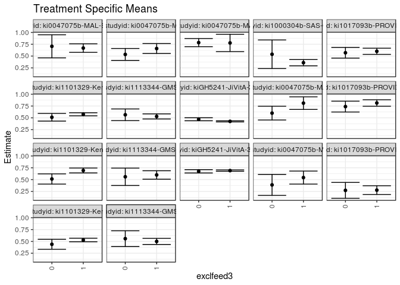

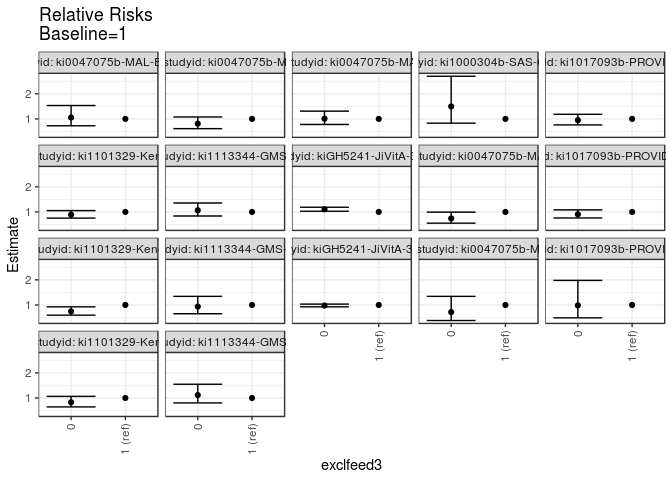

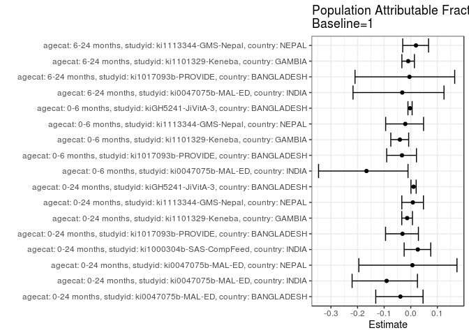

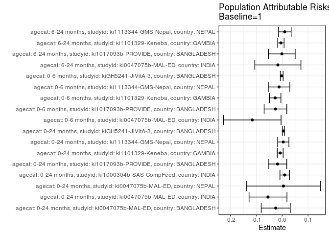

## Results Table

### Parameter: TSM

| agecat | studyid | country | intervention_level | baseline_level | estimate | ci_lower | ci_upper |
| --- | --- | --- | --- | --- | --- | --- | --- |
| 0-24 months | ki0047075b-MAL-ED | BANGLADESH | 1 | NA | 0.6691344 | 0.5788435 | 0.7594252 |
| 0-24 months | ki0047075b-MAL-ED | BANGLADESH | 0 | NA | 0.7060914 | 0.4618299 | 0.9503528 |
| 0-24 months | ki0047075b-MAL-ED | INDIA | 1 | NA | 0.6594078 | 0.5546636 | 0.7641520 |
| 0-24 months | ki0047075b-MAL-ED | INDIA | 0 | NA | 0.5344487 | 0.4084668 | 0.6604305 |
| 0-24 months | ki0047075b-MAL-ED | NEPAL | 1 | NA | 0.7777778 | 0.5946691 | 0.9608864 |
| 0-24 months | ki0047075b-MAL-ED | NEPAL | 0 | NA | 0.7846154 | 0.6984506 | 0.8707802 |
| 0-24 months | ki1000304b-SAS-CompFeed | INDIA | 1 | NA | 0.3600000 | 0.2937351 | 0.4262649 |
| 0-24 months | ki1000304b-SAS-CompFeed | INDIA | 0 | NA | 0.5384615 | 0.2364546 | 0.8404685 |
| 0-24 months | ki1017093b-PROVIDE | BANGLADESH | 1 | NA | 0.6012176 | 0.5356951 | 0.6667401 |
| 0-24 months | ki1017093b-PROVIDE | BANGLADESH | 0 | NA | 0.5699097 | 0.4569363 | 0.6828831 |
| 0-24 months | ki1101329-Keneba | GAMBIA | 1 | NA | 0.5749248 | 0.5427306 | 0.6071191 |
| 0-24 months | ki1101329-Keneba | GAMBIA | 0 | NA | 0.5123735 | 0.4314124 | 0.5933345 |
| 0-24 months | ki1113344-GMS-Nepal | NEPAL | 1 | NA | 0.5298514 | 0.4758683 | 0.5838346 |
| 0-24 months | ki1113344-GMS-Nepal | NEPAL | 0 | NA | 0.5647629 | 0.4418449 | 0.6876808 |
| 0-24 months | kiGH5241-JiVitA-3 | BANGLADESH | 1 | NA | 0.4253537 | 0.4133702 | 0.4373372 |
| 0-24 months | kiGH5241-JiVitA-3 | BANGLADESH | 0 | NA | 0.4699719 | 0.4382083 | 0.5017356 |
| 0-6 months | ki0047075b-MAL-ED | INDIA | 1 | NA | 0.8108108 | 0.6777087 | 0.9439129 |
| 0-6 months | ki0047075b-MAL-ED | INDIA | 0 | NA | 0.6000000 | 0.4545320 | 0.7454680 |
| 0-6 months | ki1017093b-PROVIDE | BANGLADESH | 1 | NA | 0.8141026 | 0.7459181 | 0.8822872 |
| 0-6 months | ki1017093b-PROVIDE | BANGLADESH | 0 | NA | 0.7382034 | 0.6236163 | 0.8527904 |
| 0-6 months | ki1101329-Keneba | GAMBIA | 1 | NA | 0.6930159 | 0.6410076 | 0.7450242 |
| 0-6 months | ki1101329-Keneba | GAMBIA | 0 | NA | 0.5134394 | 0.4053242 | 0.6215546 |
| 0-6 months | ki1113344-GMS-Nepal | NEPAL | 1 | NA | 0.5987733 | 0.5096528 | 0.6878938 |
| 0-6 months | ki1113344-GMS-Nepal | NEPAL | 0 | NA | 0.5596380 | 0.3757704 | 0.7435056 |
| 0-6 months | kiGH5241-JiVitA-3 | BANGLADESH | 1 | NA | 0.6905023 | 0.6761161 | 0.7048884 |
| 0-6 months | kiGH5241-JiVitA-3 | BANGLADESH | 0 | NA | 0.6755203 | 0.6404182 | 0.7106224 |
| 6-24 months | ki0047075b-MAL-ED | INDIA | 1 | NA | 0.5431709 | 0.4054513 | 0.6808906 |
| 6-24 months | ki0047075b-MAL-ED | INDIA | 0 | NA | 0.3882978 | 0.1663872 | 0.6102084 |
| 6-24 months | ki1017093b-PROVIDE | BANGLADESH | 1 | NA | 0.2777778 | 0.1853143 | 0.3702413 |
| 6-24 months | ki1017093b-PROVIDE | BANGLADESH | 0 | NA | 0.2727273 | 0.1045711 | 0.4408835 |
| 6-24 months | ki1101329-Keneba | GAMBIA | 1 | NA | 0.5289548 | 0.4911006 | 0.5668089 |
| 6-24 months | ki1101329-Keneba | GAMBIA | 0 | NA | 0.4389046 | 0.3333583 | 0.5444509 |
| 6-24 months | ki1113344-GMS-Nepal | NEPAL | 1 | NA | 0.4994705 | 0.4348233 | 0.5641177 |
| 6-24 months | ki1113344-GMS-Nepal | NEPAL | 0 | NA | 0.5578630 | 0.3906513 | 0.7250747 |

### Parameter: E(Y)

| agecat | studyid | country | intervention_level | baseline_level | estimate | ci_lower | ci_upper |
| --- | --- | --- | --- | --- | --- | --- | --- |
| 0-24 months | ki0047075b-MAL-ED | BANGLADESH | NA | NA | 0.6440678 | 0.5565826 | 0.7315530 |
| 0-24 months | ki0047075b-MAL-ED | INDIA | NA | NA | 0.6045198 | 0.5246128 | 0.6844268 |
| 0-24 months | ki0047075b-MAL-ED | NEPAL | NA | NA | 0.7826087 | 0.7016344 | 0.8635829 |
| 0-24 months | ki1000304b-SAS-CompFeed | INDIA | NA | NA | 0.3697479 | 0.3045176 | 0.4349782 |
| 0-24 months | ki1017093b-PROVIDE | BANGLADESH | NA | NA | 0.5830619 | 0.5262762 | 0.6398476 |
| 0-24 months | ki1101329-Keneba | GAMBIA | NA | NA | 0.5672609 | 0.5371792 | 0.5973426 |
| 0-24 months | ki1113344-GMS-Nepal | NEPAL | NA | NA | 0.5340426 | 0.4848509 | 0.5832342 |
| 0-24 months | kiGH5241-JiVitA-3 | BANGLADESH | NA | NA | 0.4298760 | 0.4185519 | 0.4412000 |
| 0-6 months | ki0047075b-MAL-ED | INDIA | NA | NA | 0.6951220 | 0.5922224 | 0.7980215 |
| 0-6 months | ki1017093b-PROVIDE | BANGLADESH | NA | NA | 0.7880435 | 0.7295878 | 0.8464992 |
| 0-6 months | ki1101329-Keneba | GAMBIA | NA | NA | 0.6657825 | 0.6181920 | 0.7133730 |
| 0-6 months | ki1113344-GMS-Nepal | NEPAL | NA | NA | 0.5866667 | 0.5072781 | 0.6660552 |
| 0-6 months | kiGH5241-JiVitA-3 | BANGLADESH | NA | NA | 0.6886463 | 0.6752359 | 0.7020567 |
| 6-24 months | ki0047075b-MAL-ED | INDIA | NA | NA | 0.5263158 | 0.4116286 | 0.6410029 |
| 6-24 months | ki1017093b-PROVIDE | BANGLADESH | NA | NA | 0.2764228 | 0.1950773 | 0.3577682 |
| 6-24 months | ki1101329-Keneba | GAMBIA | NA | NA | 0.5239207 | 0.4881434 | 0.5596979 |
| 6-24 months | ki1113344-GMS-Nepal | NEPAL | NA | NA | 0.5093750 | 0.4496016 | 0.5691484 |

### Parameter: RR

| agecat | studyid | country | intervention_level | baseline_level | estimate | ci_lower | ci_upper |
| --- | --- | --- | --- | --- | --- | --- | --- |
| 0-24 months | ki0047075b-MAL-ED | BANGLADESH | 1 | 1 | 1.0000000 | 1.0000000 | 1.0000000 |
| 0-24 months | ki0047075b-MAL-ED | BANGLADESH | 0 | 1 | 1.0552311 | 0.7263509 | 1.5330229 |
| 0-24 months | ki0047075b-MAL-ED | INDIA | 1 | 1 | 1.0000000 | 1.0000000 | 1.0000000 |
| 0-24 months | ki0047075b-MAL-ED | INDIA | 0 | 1 | 0.8104979 | 0.6106756 | 1.0757053 |
| 0-24 months | ki0047075b-MAL-ED | NEPAL | 1 | 1 | 1.0000000 | 1.0000000 | 1.0000000 |
| 0-24 months | ki0047075b-MAL-ED | NEPAL | 0 | 1 | 1.0087912 | 0.7775396 | 1.3088204 |
| 0-24 months | ki1000304b-SAS-CompFeed | INDIA | 1 | 1 | 1.0000000 | 1.0000000 | 1.0000000 |
| 0-24 months | ki1000304b-SAS-CompFeed | INDIA | 0 | 1 | 1.4957265 | 0.8288715 | 2.6990889 |
| 0-24 months | ki1017093b-PROVIDE | BANGLADESH | 1 | 1 | 1.0000000 | 1.0000000 | 1.0000000 |
| 0-24 months | ki1017093b-PROVIDE | BANGLADESH | 0 | 1 | 0.9479259 | 0.7601424 | 1.1820988 |
| 0-24 months | ki1101329-Keneba | GAMBIA | 1 | 1 | 1.0000000 | 1.0000000 | 1.0000000 |
| 0-24 months | ki1101329-Keneba | GAMBIA | 0 | 1 | 0.8912008 | 0.7542241 | 1.0530542 |
| 0-24 months | ki1113344-GMS-Nepal | NEPAL | 1 | 1 | 1.0000000 | 1.0000000 | 1.0000000 |
| 0-24 months | ki1113344-GMS-Nepal | NEPAL | 0 | 1 | 1.0658891 | 0.8380014 | 1.3557489 |
| 0-24 months | kiGH5241-JiVitA-3 | BANGLADESH | 1 | 1 | 1.0000000 | 1.0000000 | 1.0000000 |
| 0-24 months | kiGH5241-JiVitA-3 | BANGLADESH | 0 | 1 | 1.1048968 | 1.0284191 | 1.1870618 |
| 0-6 months | ki0047075b-MAL-ED | INDIA | 1 | 1 | 1.0000000 | 1.0000000 | 1.0000000 |
| 0-6 months | ki0047075b-MAL-ED | INDIA | 0 | 1 | 0.7400000 | 0.5521528 | 0.9917544 |
| 0-6 months | ki1017093b-PROVIDE | BANGLADESH | 1 | 1 | 1.0000000 | 1.0000000 | 1.0000000 |
| 0-6 months | ki1017093b-PROVIDE | BANGLADESH | 0 | 1 | 0.9067694 | 0.7598100 | 1.0821531 |
| 0-6 months | ki1101329-Keneba | GAMBIA | 1 | 1 | 1.0000000 | 1.0000000 | 1.0000000 |
| 0-6 months | ki1101329-Keneba | GAMBIA | 0 | 1 | 0.7408768 | 0.5935501 | 0.9247718 |
| 0-6 months | ki1113344-GMS-Nepal | NEPAL | 1 | 1 | 1.0000000 | 1.0000000 | 1.0000000 |
| 0-6 months | ki1113344-GMS-Nepal | NEPAL | 0 | 1 | 0.9346408 | 0.6510019 | 1.3418601 |
| 0-6 months | kiGH5241-JiVitA-3 | BANGLADESH | 1 | 1 | 1.0000000 | 1.0000000 | 1.0000000 |
| 0-6 months | kiGH5241-JiVitA-3 | BANGLADESH | 0 | 1 | 0.9783028 | 0.9257193 | 1.0338732 |
| 6-24 months | ki0047075b-MAL-ED | INDIA | 1 | 1 | 1.0000000 | 1.0000000 | 1.0000000 |
| 6-24 months | ki0047075b-MAL-ED | INDIA | 0 | 1 | 0.7148722 | 0.3807521 | 1.3421914 |
| 6-24 months | ki1017093b-PROVIDE | BANGLADESH | 1 | 1 | 1.0000000 | 1.0000000 | 1.0000000 |
| 6-24 months | ki1017093b-PROVIDE | BANGLADESH | 0 | 1 | 0.9818182 | 0.4873998 | 1.9777746 |
| 6-24 months | ki1101329-Keneba | GAMBIA | 1 | 1 | 1.0000000 | 1.0000000 | 1.0000000 |
| 6-24 months | ki1101329-Keneba | GAMBIA | 0 | 1 | 0.8297582 | 0.6460539 | 1.0656987 |
| 6-24 months | ki1113344-GMS-Nepal | NEPAL | 1 | 1 | 1.0000000 | 1.0000000 | 1.0000000 |
| 6-24 months | ki1113344-GMS-Nepal | NEPAL | 0 | 1 | 1.1169088 | 0.8055843 | 1.5485471 |

### Parameter: PAR

| agecat | studyid | country | intervention_level | baseline_level | estimate | ci_lower | ci_upper |
| --- | --- | --- | --- | --- | --- | --- | --- |
| 0-24 months | ki0047075b-MAL-ED | BANGLADESH | 1 | NA | -0.0250666 | -0.0811986 | 0.0310654 |
| 0-24 months | ki0047075b-MAL-ED | INDIA | 1 | NA | -0.0548880 | -0.1281354 | 0.0183594 |
| 0-24 months | ki0047075b-MAL-ED | NEPAL | 1 | NA | 0.0048309 | -0.1385574 | 0.1482192 |
| 0-24 months | ki1000304b-SAS-CompFeed | INDIA | 1 | NA | 0.0097479 | -0.0087899 | 0.0282857 |
| 0-24 months | ki1017093b-PROVIDE | BANGLADESH | 1 | NA | -0.0181557 | -0.0539652 | 0.0176537 |
| 0-24 months | ki1101329-Keneba | GAMBIA | 1 | NA | -0.0076639 | -0.0190502 | 0.0037225 |
| 0-24 months | ki1113344-GMS-Nepal | NEPAL | 1 | NA | 0.0041911 | -0.0175003 | 0.0258826 |
| 0-24 months | kiGH5241-JiVitA-3 | BANGLADESH | 1 | NA | 0.0045223 | 0.0003189 | 0.0087257 |
| 0-6 months | ki0047075b-MAL-ED | INDIA | 1 | NA | -0.1156889 | -0.2269651 | -0.0044126 |
| 0-6 months | ki1017093b-PROVIDE | BANGLADESH | 1 | NA | -0.0260592 | -0.0698043 | 0.0176860 |
| 0-6 months | ki1101329-Keneba | GAMBIA | 1 | NA | -0.0272334 | -0.0494384 | -0.0050284 |
| 0-6 months | ki1113344-GMS-Nepal | NEPAL | 1 | NA | -0.0121067 | -0.0537761 | 0.0295628 |
| 0-6 months | kiGH5241-JiVitA-3 | BANGLADESH | 1 | NA | -0.0018560 | -0.0072911 | 0.0035791 |
| 6-24 months | ki0047075b-MAL-ED | INDIA | 1 | NA | -0.0168551 | -0.1059622 | 0.0722520 |
| 6-24 months | ki1017093b-PROVIDE | BANGLADESH | 1 | NA | -0.0013550 | -0.0528032 | 0.0500932 |
| 6-24 months | ki1101329-Keneba | GAMBIA | 1 | NA | -0.0050341 | -0.0173536 | 0.0072853 |
| 6-24 months | ki1113344-GMS-Nepal | NEPAL | 1 | NA | 0.0099045 | -0.0147747 | 0.0345836 |

### Parameter: PAF

| agecat | studyid | country | intervention_level | baseline_level | estimate | ci_lower | ci_upper |
| --- | --- | --- | --- | --- | --- | --- | --- |
| 0-24 months | ki0047075b-MAL-ED | BANGLADESH | 1 | NA | -0.0389192 | -0.1315439 | 0.0461236 |
| 0-24 months | ki0047075b-MAL-ED | INDIA | 1 | NA | -0.0907961 | -0.2204970 | 0.0251217 |
| 0-24 months | ki0047075b-MAL-ED | NEPAL | 1 | NA | 0.0061728 | -0.1952351 | 0.1736417 |
| 0-24 months | ki1000304b-SAS-CompFeed | INDIA | 1 | NA | 0.0263636 | -0.0248925 | 0.0750564 |
| 0-24 months | ki1017093b-PROVIDE | BANGLADESH | 1 | NA | -0.0311386 | -0.0946688 | 0.0287046 |
| 0-24 months | ki1101329-Keneba | GAMBIA | 1 | NA | -0.0135103 | -0.0337939 | 0.0063753 |
| 0-24 months | ki1113344-GMS-Nepal | NEPAL | 1 | NA | 0.0078479 | -0.0336275 | 0.0476591 |
| 0-24 months | kiGH5241-JiVitA-3 | BANGLADESH | 1 | NA | 0.0105200 | 0.0006961 | 0.0202473 |
| 0-6 months | ki0047075b-MAL-ED | INDIA | 1 | NA | -0.1664296 | -0.3465073 | -0.0104349 |
| 0-6 months | ki1017093b-PROVIDE | BANGLADESH | 1 | NA | -0.0330682 | -0.0904986 | 0.0213377 |
| 0-6 months | ki1101329-Keneba | GAMBIA | 1 | NA | -0.0409044 | -0.0750037 | -0.0078867 |
| 0-6 months | ki1113344-GMS-Nepal | NEPAL | 1 | NA | -0.0206364 | -0.0942961 | 0.0480651 |
| 0-6 months | kiGH5241-JiVitA-3 | BANGLADESH | 1 | NA | -0.0026951 | -0.0106198 | 0.0051674 |
| 6-24 months | ki0047075b-MAL-ED | INDIA | 1 | NA | -0.0320248 | -0.2170297 | 0.1248569 |
| 6-24 months | ki1017093b-PROVIDE | BANGLADESH | 1 | NA | -0.0049020 | -0.2095297 | 0.1651070 |
| 6-24 months | ki1101329-Keneba | GAMBIA | 1 | NA | -0.0096086 | -0.0334070 | 0.0136418 |
| 6-24 months | ki1113344-GMS-Nepal | NEPAL | 1 | NA | 0.0194443 | -0.0302768 | 0.0667659 |